# Part 3: Plotting the Vowels

Author

Bethany Gardner

Published

January 30, 2024

Now to actually make the vowel plots! This document goes into detail about how I decided to make them the way I did and how to implement them in ggplot, but if you just want to see the final results, jump down to here.

### 3.1 Setup

```r
library(tidyverse)
library(magrittr)
library(ggtext)
library(ggforce)
library(ggrepel)
library(rcartocolor)
library(png)
library(patchwork)

options(dplyr.summarise.inform = FALSE)
```

**1**

Data wrangling (`tidyr`, `dplyr`, `purrr`, `stringr`), `ggplot2` for plotting.

**2**

Pipe operator.

**3**

Markdown/HTML formatting for text in plots.

**4**

Ellipsis plots.

**5**

Offset text labels from points.

**6**

Color themes.

**7**

Open PNG images.

**8**

Add images on top of plots.

**9**

Don’t print a message every time `summarise()` is called on a grouped dataframe.

(Note: this could be done in Python, but I strongly prefer the [ggplot package](https://ggplot2.tidyverse.org/) for plotting.)

#### Data

Load the vowel formant data from Part 2:

```r
formants <- read.csv("data/formants.csv", stringsAsFactors = TRUE) %>%
  select(-Vowel_Time, -Count) %>%
  mutate(
    Speaker = ifelse(Speaker == "G", "Gretchen", "Lauren"),
    List = ifelse(
      List == "episode", "Lingthusiasm Episodes", "Wells Lexical Set"
    )
  ) %>%
  mutate(across(where(is.character), as.factor))

str(formants)
```

**1**

Read formants data from `2_annotate_audio.qmd`, and keep columns for `List`, `Vowel`, `Word`, `Speaker`, `F1`, and `F2`.

**2**

Recode the values for `Speaker` and `List` from abbreviations to full strings for plot labels, then make them both factors.

```
'data.frame':   397 obs. of  6 variables:
 $ List   : Factor w/ 2 levels "Lingthusiasm Episodes",..: 1 1 1 1 1 1 1 1 1 1 ...
 $ Vowel  : Factor w/ 11 levels "ɑ","æ","ɔ","ə",..: 4 4 4 4 4 4 4 4 4 4 ...
 $ Word   : Factor w/ 47 levels "among","another",..: 1 1 1 1 1 1 1 1 1 1 ...
 $ Speaker: Factor w/ 2 levels "Gretchen","Lauren": 1 1 1 1 1 2 2 2 2 2 ...
 $ F1     : num  766 602 733 766 626 ...
 $ F2     : num  1260 1254 1175 1373 1260 ...
```

#### IPA Symbols

However, the IPA symbols aren’t encoded correctly. They’ll render in RStudio, but not when Quarto renders the document to HTML, or always when ggplot renders the plots. This isn’t what we want:

> ɑ, æ, ɔ, ə, ɛ, i, ɪ, o, u, ʊ, ʌ

So, the next step is to enter the unicode values manually (copied from this [Wikipedia page](https://en.wikipedia.org/wiki/Phonetic_symbols_in_Unicode#Vowels)):

```r
vowels <- c(
  "i_lower"   = "\u0069",  # i (close front unrounded)
  "i_upper"   = "\u026A",  # ɪ (near-close front unrounded)
  "epsilon"   = "\u025B",  # ɛ (open-mid front unrounded)
  "ash"       = "\u00E6",  # æ (near-open front unrounded)
  "schwa"     = "\u0259",  # ə (mid central)
  "horseshoe" = "\u028A",  # ʊ (near-close near-back rounded)
  "u"         = "\u0075",  # u (close back rounded)
  "o"         = "\u006F",  # o (close-mid back rounded)
  "hat"       = "\u028C",  # ʌ (open-mid back unrounded)
  "open_o"    = "\u0254",  # ɔ (open-mid back rounded)
  "alpha"     = "\u0251"   # ɑ (open back unrounded)
)
```

These are ordered from front to back, then close to open (Figure 4).

Then match the unicode for the IPA symbol to the words:

```r
formants %<>% mutate(
  Vowel = case_when(
    Word %in% c("ball", "father", "honorific", "lot", "palm", "start") ~ vowels["alpha"],
    Word %in% c("bang", "bath", "hand", "laugh", "trap") ~ vowels["ash"],
    Word %in% c("bought", "cloth", "core", "north", "thought", "wrong") ~ vowels["open_o"],
    Word %in% c("among", "famous", "support") ~ vowels["schwa"],
    Word %in% c("bet", "dress", "guest", "says", "square") ~ vowels["epsilon"],
    Word %in% c("beat", "believe", "fleece", "people") ~ vowels["i_lower"],
    Word %in% c("bit", "finish", "kit", "near", "pin") ~ vowels["i_upper"],
    Word %in% c("force", "goat") ~ vowels["o"],
    Word %in% c("blue", "goose", "through", "who") ~ vowels["u"],
    Word %in% c("could", "cure", "put", "foot") ~ vowels["horseshoe"],
    Word %in% c("another", "but", "fun", "strut") ~ vowels["hat"],
  ) %>% factor(levels = vowels, ordered = TRUE)
)

str(formants)
```

**1**

If the value in the `Word` column is `ball`, `father`, `honorific`, `lot`, or `palm`, then assign the `alpha` value from the `vowels` list.

**2**

Convert character to factor, then specify the order of the factors (same as in `vowels` list above) to make sure it stays consistent.

```
'data.frame':   397 obs. of  6 variables:
 $ List   : Factor w/ 2 levels "Lingthusiasm Episodes",..: 1 1 1 1 1 1 1 1 1 1 ...
 $ Vowel  : Ord.factor w/ 11 levels "i"<"ɪ"<"ɛ"<"æ"<..: 5 5 5 5 5 5 5 5 5 5 ...
  ..- attr(*, "names")= chr [1:397] "schwa" "schwa" "schwa" "schwa" ...
 $ Word   : Factor w/ 47 levels "among","another",..: 1 1 1 1 1 1 1 1 1 1 ...
 $ Speaker: Factor w/ 2 levels "Gretchen","Lauren": 1 1 1 1 1 2 2 2 2 2 ...
 $ F1     : num  766 602 733 766 626 ...
 $ F2     : num  1260 1254 1175 1373 1260 ...
```

Now the IPA vowels consistently render correctly:

> i, ɪ, ɛ, æ, ə, ʊ, u, o, ʌ, ɔ, ɑ

#### Lingthusiasm Theme

The Lingthusiasm font is `Josefin Sans`, which is available from [Google Fonts](https://fonts.google.com/specimen/Josefin+Sans/glyphs).

I downloaded and installed it to my computer. There are a number of different ways to add new fonts without having to install them separately outside of RStudio, such as `font_add_google()` from the [showtext package](https://cran.rstudio.com/web/packages/showtext/vignettes/introduction.html). However, that method was causing errors rendering the IPA symbols.

`systemfonts()` shows the list of fonts installed on my computer that R recognizes, and it finds Josefin Sans:

```r
systemfonts::system_fonts() %>%
  filter(str_detect(family, "Josefin Sans")) %>%
  select(path, name, family) %>%
  pivot_longer(cols = everything())
```

**1**

Get dataframe of fonts available.

**2**

Filter to include `Josefin Sans`.

**3**

Select columns to print; flip to list vertically.

```
# A tibble: 3 × 2
  name   value
  <chr>  <chr>
1 path   "C:\\Users\\betha\\AppData\\Local\\Microsoft\\Windows\\Fonts\\JosefinS…
2 name   "JosefinSans-Thin"
3 family "Josefin Sans"
```

However, the fonts loaded by default just include Times New Roman, Arial, and Courier New:

```r
windowsFonts()
```

```
$serif
[1] "TT Times New Roman"

$sans
[1] "TT Arial"

$mono
[1] "TT Courier New"
```

This tells R to load Josefin Sans into the set of available fonts, so text will render in Josefin Sans if `family = sans_alt`, but stick with the default sans font otherwise (and not break the IPA symbols).

```r
windowsFonts(sans_alt = "Josefin Sans")
windowsFonts()
```

```
$serif
[1] "TT Times New Roman"

$sans
[1] "TT Arial"

$mono
[1] "TT Courier New"

$sans_alt
[1] "Josefin Sans"
```

The hex codes for the green and navy are:

```r
lingthusiasm_green = "#26b14c"
lingthusiasm_navy = "#051458"
```

And the logo:

```r
lingthusiasm_logo <- readPNG("resources/lingthusiasm_logo_circle.png",  native = TRUE)
lingthusiasm_tagline <- readPNG("resources/lingthusiasm_logo_tagline.png",  native = TRUE)
```

**1**

Read logo images. `native = TRUE` specifies reading it as a raster object instead of an array, which is the format `patchwork::inset_element()` needs.

Putting it together:

```r
tibble(
  "Color" = c("green", "navy"),
  "Hex" = c(lingthusiasm_green, lingthusiasm_navy),
  "Extra_Col" = c(1, 1)
) %>%
  ggplot(aes(x = Color, y = Extra_Col, fill = Hex, label = Hex)) +
  geom_tile() +
  geom_text(size = 10, color = "white") +
  scale_fill_identity() +
  theme_classic() +
  labs(title = "Lingthusiasm Theme") +
  theme(
    plot.title = element_text(
      family = "sans_alt", size = 28,
      margin = margin(t = 1, b = 1, unit = "lines"), hjust = 0.55,
      color = lingthusiasm_navy
    ),
    axis.text = element_blank(), axis.title = element_blank(),
    axis.line = element_blank(), axis.ticks = element_blank()
  ) +
  inset_element(
    p = lingthusiasm_logo,
    left = unit(0.05, "snpc"), right = unit(0.25, "snpc"),
    top = unit(1.2, "snpc"), bottom = unit(1, "snpc")
  )
```

**1**

`Color` is names of the two lingthusiasm theme colors.

**2**

`Hex` is the two hex codes.

**3**

`Extra_Col` is a dummy value because ggplot needs a Y axis.

**4**

The X axis is `Color`, and the Y axis is `Extra_Col`, which just creates two boxes next to each other. Fill and label are specified by `Hex`.

**5**

Draw a square for each color.

**6**

Label the squares with the hex code strings (keeping the default font).

**7**

Fill the squares with the hex code color values.

**8**

Set the plot title text to be navy, Josefin Sans, size 28, centered with some space above and below.

**9**

Remove the axis lines, labels, titles, and ticks.

**10**

Use the `patchwork` package to add the logo image on top of the plot. This step needs to be last.

**11**

Specify the positions for each corner of the logo, using `spnc` units so it stays square even if the overall plot is rectangular.

[figure not shown]

Figure 1: Lingthusiasm colors, font, and logo.

### 3.2 Plot Vowel Means

Now let’s take a look at the data! F1 gets plotted on the Y axis, and F2 gets plotted on the X axis.

```r
means_1 <- formants %>%
  group_by(Speaker, List, Vowel) %>%
  summarise(F1 = mean(F1), F2 = mean(F2)) %>%
  ggplot(aes(x = F2, y = F1, label = Vowel)) +
  geom_textbox(
    fill = lingthusiasm_green, box.colour = NA,
    color = "white", size = 4.5, halign = 0.5, valign = 0.5,
    width = unit(0.10, "snpc"), height = unit(0.10, "snpc"),
    box.padding = unit(c(0, 0, 0, 0), "snpc"), box.r = unit(0.01, "snpc")
  ) +
  facet_grid(Speaker ~ List) +
  theme_classic() +
  theme(
    axis.line = element_line(color = lingthusiasm_navy),
    axis.ticks = element_line(color = lingthusiasm_navy),
    panel.border = element_rect(color = lingthusiasm_navy, fill = NA),
    strip.background = element_rect(color = lingthusiasm_navy),
    text = element_text(size = 12, family = "sans_alt", color = lingthusiasm_navy),
    axis.text = element_text(color = lingthusiasm_navy),
    strip.text = element_text(color = lingthusiasm_navy, size = 12)
  ) +
  labs(title = "Vowel Means")

means_1
```

**1**

Take the full data set, group it by `Speaker` then `List` then `Vowel`, and then calculate the means of `F1` and `F2` for each `Speaker` x `List` x `Vowel`.

**2**

All layers of the plot have `F2` on the X axis, `F1` on the Y axis, and are labelled by `Vowel`.

**3**

Write the vowel symbols (because `Label = Vowel`) at the location of their means.

**4**

Make the text box background lingthusiasm green with no outline.

**5**

Make the text white, size 4.5 (note that this is on a different scale than the rest of the text sizes specified in later `theme()`), vertically and horizontally centered.

**6**

Set the size of the text boxes, using `snpc` (squared normalized parent coordinates) to be relative to the size of the plot but always square.

**7**

No margins inside the text boxes and a slight curve on the corners.

**8**

Split the plot to have Gretchen’s data in the top panels and Lauren’s data in the bottom panels, and the data from the Lingthusiasm episodes in the left panels and the data from the Wells lexical set recordings in the right panels.

**9**

Change the default theme to have a white background with no grid lines.

**10**

Change all the lines (axis lines, axis ticks, outline around panels, outline around panel labels) to be the lingthusiasm navy.

**11**

**12**

Set the title, and leave the other axis/legend labels as their default values of “F1”, “F2”, and “Vowel.”

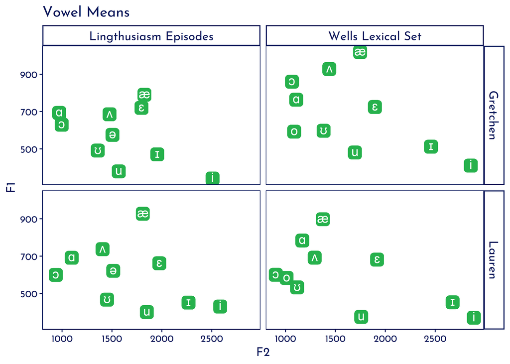

Figure 2: Vowel means (default axes).

(Sidenote: saving the theme specifications so we don’t have to keep retyping theme.)

```r
lingthusiasm_theme <- theme(
  axis.line = element_line(color = lingthusiasm_navy),
  axis.ticks = element_line(color = lingthusiasm_navy),
  panel.border = element_rect(color = lingthusiasm_navy, fill = NA),
  strip.background = element_rect(color = lingthusiasm_navy),
  text = element_text(size = 12, family = "sans_alt", color = lingthusiasm_navy),
  axis.text = element_text(color = lingthusiasm_navy),
  strip.text = element_text(color = lingthusiasm_navy, size = 12)
)
```

However, vowel plots typically have their axes reversed, so that the highest value of (F1, F2) is at the bottom left corner instead of the top right corner. This isn’t standard data visualization procedure, but it has a cool and useful result.

```r
means_2 <- formants %>%
  group_by(List, Speaker, Vowel) %>%
  summarise(F1 = mean(F1), F2 = mean(F2)) %>%
  ggplot(aes(x = F2, y = F1, label = Vowel)) +
  geom_textbox(
    fill = lingthusiasm_green, box.colour = NA,
    color = "white", size = 4.5, halign = 0.5, valign = 0.5,
    width = unit(0.10, "snpc"), height = unit(0.10, "snpc"),
    box.padding = unit(c(0, 0, 0, 0), "snpc"), box.r = unit(0.01, "snpc")
  ) +
  facet_grid(Speaker ~ List) +
  scale_x_reverse(breaks = c(1000, 1500, 2000, 2500)) +
  scale_y_reverse(limits = c(1050, 225), n.breaks = 4) +
  theme_classic() +
  lingthusiasm_theme +
  labs(title = "Vowel Means")

means_2
```

**1**

Just annotating the lines that changed from the previous chunk.

**2**

Add this to flip the X axis. Specify `breaks` because the default values aren’t even.

**3**

Add this to flip the Y axis. The limits (see how they’re reversed) are specified because the defaults were a bit too narrow, and like this the axis ticks/labels are spaced more evenly.

**4**

Add this to specify the colors and font sizes etc.

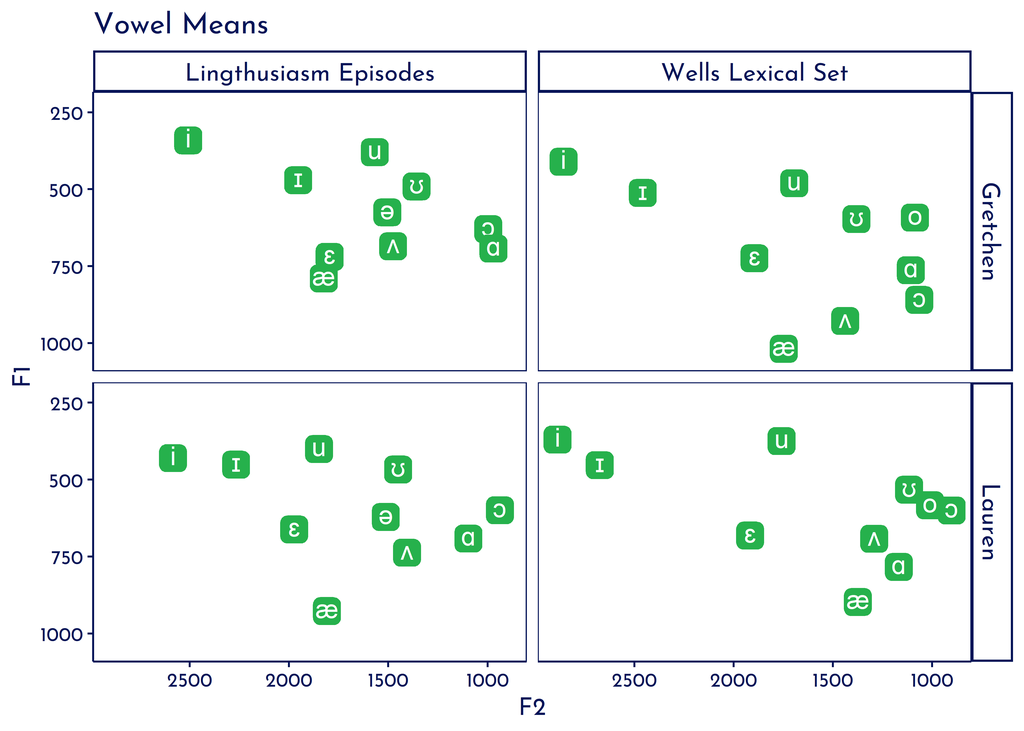

Figure 3: Vowel means (reversed axes).

Now the layout resembles the IPA vowel chart! Front vowels are on the left, and back vowels are on the right; close vowels are on the top, and open vowels are on the bottom.

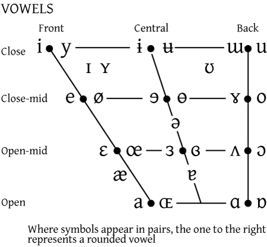

Figure 4: IPA Vowel Chart.

### 3.3 Plot Individual Data Points

Just plotting the means for each vowel loses a lot of information, so let’s take a look at the underlying data.

Now, we’ll distinguish between vowels by color. First, make a legend that will be easier to read than the default by creating a string that prints each vowel in its corresponding color (using the [ggtext package](https://wilkelab.org/ggtext/) to render the HTML formatting).

```r
vowel_key <- tibble("Vowel" = vowels, "Color" = carto_pal(12, "Bold")[1:11]) %>%
  mutate(Styled = str_c("<b style='color:", Color, "'>", Vowel, "</b>")) %>%
  pull(Styled) %>%
  str_flatten(collapse = ", ")

vowel_key %>% str_wrap(32) %>% str_view()
```

**1**

**2**

Encase with HTML code, so that hex code becomes a `color` argument for the vowel character.

**3**

Merge into 1 string, with each value separated by a comma + space. 4.. Print, wrapping lines on each item.

```
[1] │ <b style='color:#7F3C8D'>i</b>,
    │ <b style='color:#11A579'>ɪ</b>,
    │ <b style='color:#3969AC'>ɛ</b>,
    │ <b style='color:#F2B701'>æ</b>,
    │ <b style='color:#E73F74'>ə</b>,
    │ <b style='color:#80BA5A'>ʊ</b>,
    │ <b style='color:#E68310'>u</b>,
    │ <b style='color:#008695'>o</b>,
    │ <b style='color:#CF1C90'>ʌ</b>,
    │ <b style='color:#F97B72'>ɔ</b>,
    │ <b style='color:#4B4B8F'>ɑ</b>
```

Which will render like this:

> **i**, **ɪ**, **ɛ**, **æ**, **ə**, **ʊ**, **u**, **o**, **ʌ**, **ɔ**, **ɑ**

(Note that ggplot will throw a warning like `Warning in text_info(label, fontkey, fontfamily, font, fontsize, cache): unable to translate 'ɑpng215' to native encoding`, but it renders correctly, so the warnings are turned off in those code chunks.)

```r
points <- formants %>%
  ggplot(aes(x = F2, y = F1, color = Vowel, label = Vowel)) +
  geom_point(size = 1.5) +
  facet_grid(Speaker ~ List) +
  scale_color_manual(values = carto_pal(12, "Bold")) +
  scale_x_reverse(breaks = c(750, 1250, 1750, 2250, 2750)) +
  scale_y_reverse(breaks = c(250, 500, 750, 1000)) +
  theme_classic() +
  lingthusiasm_theme +
  theme(plot.subtitle = element_markdown(family = "sans")) +
  labs(title = "Individual Data Points", subtitle = vowel_key) +
  guides(color = guide_none())

points
```

**1**

Passing the full data set, not the means by `Speaker` + `Vowel` + `List`, to ggplot.

**2**

Instead of `geom_text()`, `geom_point()` is a layer drawing scatterplot (`size` making the points slightly bigger than default).

**3**

Use the `Bold` color palette from the `rcartocolor` package to color-code the vowels. (There are 11 vowels, but I specify 12 colors here so the grey gets skipped.)

**4**

**5**

`element_markdown()` from `ggtext` will render the HTML string. Use default sans serif font because Josefin Sans doesn’t have all of the IPA symbols.

**6**

Add the color-coded list of vowels as a subtitle.

**7**

Turn the default legend off.

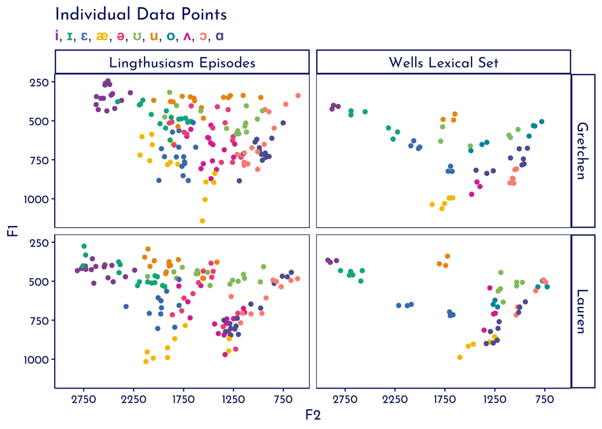

Figure 5: Individual data points.

Save the plots:

```r
ggsave(
  means_1, path = "plots", filename = "1_means_original.png",
  width = 8, height = 5, unit = "in", device = png
)
ggsave(
  means_2, path = "plots", filename = "2_means_flipped.png",
  width = 8, height = 5, unit = "in", device = png
)
ggsave(
  points, path = "plots", filename = "3_individual_points.png",
  width = 8, height = 5, unit = "in", device = png
)
```

**1**

Need to specify `device = png` (not leave default or `device = "png"`) to get Josefin Sans font to render correctly.

## Citation

BibTeX citation:

```
@online{gardner2024,
  author = {Gardner, Bethany},
  title = {Lingthusiasm {Vowel} {Plots}},
  date = {2024-01-30},
  url = {https://bethanyhgardner.github.io/lingthusiasm-vowel-plots},
  langid = {en}
}
```

For attribution, please cite this work as:

Gardner, Bethany. 2024. “Lingthusiasm Vowel Plots.” January 30, 2024. https://bethanyhgardner.github.io/lingthusiasm-vowel-plots.